# The weather

Valtýr

2021-04-24

After moving to Skagaströnd I became a weather enthusiast. The weather here has such clear patterns that I hadn’t realized before. In winter a north-east wind brings snow from the highlands that piles up behind every obsticle downwind, so houses that have front doors not facing the blizzard are covered with snow.

[figure not shown]

Not a single snowflake comes from the clouds above, it’s all from the highlands in the north east, and it’s densely packed snow powder. Southern winds are more frequent in winter but they don’t have the same effect. They’re not as strong and do usually not involve a snow storm.

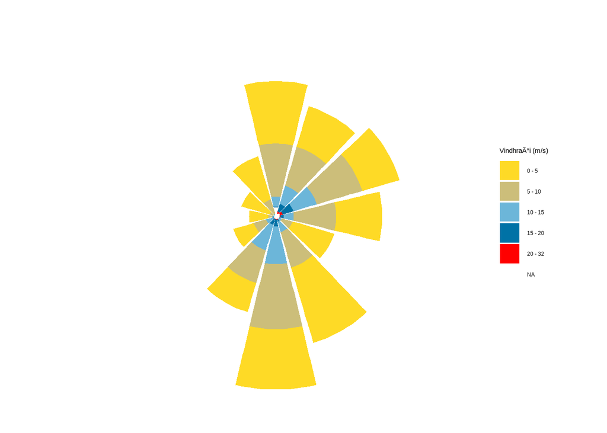

```r
df <- vedur %>%   mutate(manudur = format(Timabil, "%m"),
                      man = format(Timabil, "%b")) %>%
  group_by(manudur)
df$manudur = factor(format(strptime(df$Timabil,'%Y-%m-%d'),'%b'), levels=format(ISOdate(2000, 1:12, 1), "%b"), ordered=TRUE)

p.wr2 <- plot.windrose(data = df,
                       spd = "Vindur (m/s)",
                       dir = "Vindatt (deg)")
```

Windroses are available for any area of Iceland https://vindatlas.vedur.is/ but they don’t have seasonality.

```r
p <- p.wr2 + facet_wrap(~manudur, nrow = 3) +
p
```

[output not shown]